# Estado Viável mas não Cultivável: Bibliometria

Apresenta um mapa de rede cronológica das citações diretas mais relevantes resultantes de uma coleção bibliográfica.

A função que gera a matriz desta rede é:

```r
options(width=130)
histResults <- histNetwork(M, min.citations = 10, sep = ";")
```

```
## Articles analysed   100
## Articles analysed   200
## Articles analysed   300
## Articles analysed   374
```

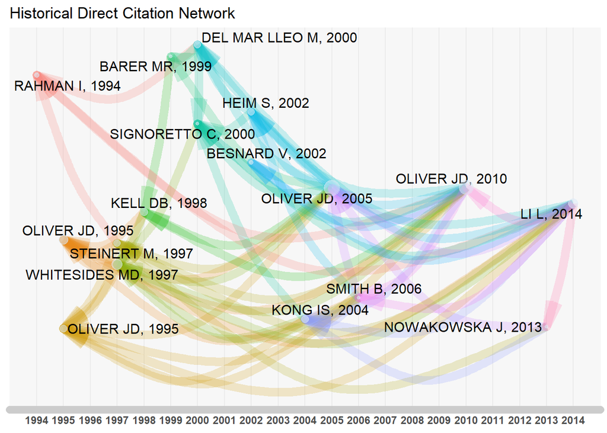

```
##
##  Legend
##
##                                                                     Paper                              DOI Year LCS GCS
## 1994 - 1                           RAHMAN I, 1994, APPL ENVIRON MICROBIOL                             <NA> 1994  35 112
## 1995 - 2                          OLIVER JD, 1995, APPL ENVIRON MICROBIOL                             <NA> 1995  61 199
## 1995 - 5                        OLIVER JD, 1995, APPL ENVIRON MICROBIOL-a                             <NA> 1995  46 189
## 1997 - 10                        STEINERT M, 1997, APPL ENVIRON MICROBIOL                             <NA> 1997  45 277
## 1997 - 11                     WHITESIDES MD, 1997, APPL ENVIRON MICROBIOL                             <NA> 1997  77 161
## 1998 - 18  KELL DB, 1998, ANTONIE VAN LEEUWENHOEK INT J GEN MOL MICROBIOL          10.1023/A:1000664013047 1998  50 407
## 1999 - 35                              BARER MR, 1999, ADV MICROB PHYSIOL                             <NA> 1999  33 245
## 2000 - 41                      SIGNORETTO C, 2000, APPL ENVIRON MICROBIOL  10.1128/AEM.66.5.1953-1959.2000 2000  33 114
## 2000 - 48                    DEL MAR LLEO M, 2000, APPL ENVIRON MICROBIOL 10.1128/AEM.66.10.4564-4567.2000 2000  43 140
## 2002 - 69                                       HEIM S, 2002, J BACTERIOL 10.1128/JB.184.23.6739-6745.2002 2002  45 127
## 2002 - 78                                        BESNARD V, 2002, VET RES           10.1051/VETRES:2002022 2002  34  78
## 2004 - 94                              KONG IS, 2004, FEMS MICROBIOL ECOL     10.1016/J.FEMSEC.2004.06.004 2004  48  87
## 2005 - 121                                   OLIVER JD, 2005, J MICROBIOL                             <NA> 2005 159 757
## 2006 - 139                          SMITH B, 2006, APPL ENVIRON MICROBIOL  10.1128/AEM.72.2.1445-1451.2006 2006  33  75
## 2010 - 232                            OLIVER JD, 2010, FEMS MICROBIOL REV 10.1111/J.1574-6976.2009.00200.X 2010 137 546
## 2013 - 296                        NOWAKOWSKA J, 2013, FEMS MICROBIOL ECOL          10.1111/1574-6941.12052 2013  33  57
## 2014 - 311                                    LI L, 2014, FRONT MICROBIOL         10.3389/FMICB.2014.00258 2014  67 223
```

```r
net <- histPlot(histResults, n=15, size = 20, labelsize=10, size.cex=TRUE, arrowsize = 0.5, color = TRUE)
```

## Dificuldades Encontradas e Respostas alcançadas

### Instalação do pacote Bibliometrix

Inicialmente pacote Bibliometrix foi instalado da seguinte forma:

install.packages(“bibliometrix”, dependencies=TRUE, repos = “http://cran.us.r-project.org”)

No entanto, o mesmo apresentava erros ao carregar.

A solução foi desinstalar o pacote, e instalar novamente segundo orientações descritas no item 1 deste documento.

### Arquivo no formato PDF

A maior dificuldade encontrada ao longo do desenvolvimento deste projeto foi com relação a geração do PDF do arquivo de trabalho no formato Rmd. No entanto, apesar de várias buscas em foruns na tentativa de solicionar o problema, só consegui solucionar o mesmo trabalhando em um computador diferente.

### Obtenção de dados

Ao converter o resultado da busca da pltaforma SCOPUS para o formato bibtex pela primeira vez, não selecionei todos os campos para exportar o arquivo. O mesmo apresentava erros no momento de excultar as funções para as análises. A solução foi exportar novamente o arquivo, desta vez com todos os campos selecionados (ex., Authors, title, source, etc.).

### Gráficos Co-Word

Os gráficos gerados de Co-word, item 16 deste arquivo, “Conceptual struture map” pelo método CA e o dendograma ficaram difíceis de serem análisados devido a grande quantidade de informações contidas. Acredito que a solução para evitar gráficos carregados de informações, principalmente quando se refere aos gráficos de redes, seria refinar as buscas nos bancos de dados bibliográficos utilizando palavras chaves mais específicas refente ao tema.

### Formatação

Quando é gerado o pdf do aquivo no formato Rmd o mesmo apresenta problemas na formatação, pois os resultados de saída ultrapassam a margem do documento. Acredito que uma solução seria gerar o aquivo com as páginas configuradas em paisagem, por exemplo. Mas não consegui solucionar este problema.

## Referências bibliográficas

Aria, M. & Cuccurullo, C. (2017) bibliometrix: An R-tool for comprehensive science mapping analysis, Journal of Informetrics, 11(4), pp 959-975, Elsevier.

Aria, M. & Cuccurullo, C. (2017). A brief introduction to bibliometrix. Disponível em: https://cran.r-project.org/web/packages/bibliometrix/vignettes/bibliometrix-vignette.html. Acesso em: maio, 2019.